**Deep Neural Operators**

By Prof. Seungchul Lee  
http://iailab.kaist.ac.kr/  
Industrial AI Lab at KAIST

Table of Contents

# 1. Deep Neural Operators

## 1.1. Limitations of PINN

PINNs have gained significant attention for their ability to solve forward and inverse problems governed by partial differential equations (PDEs). Their success has been demonstrated across numerous applications, including fluid dynamics, heat transfer, and material science. By embedding physics directly into the learning process, PINNs provide a data-efficient alternative to traditional numerical solvers.

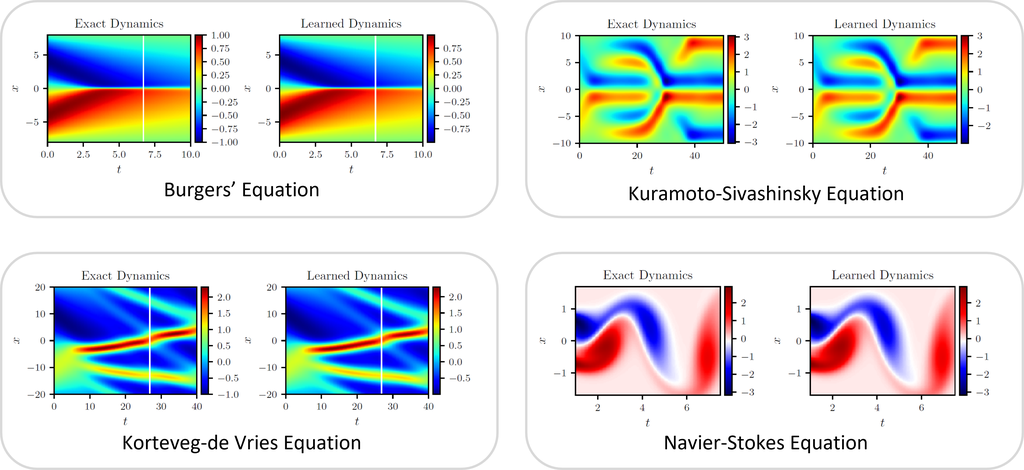

However, despite their advantages, PINNs have clear limitations that hinder their broader applicability:

- **Single Instance Solver**
  - A trained PINN model is designed to solve a **specific instance** of a PDE problem.
  - In other words, PINN models can accurately predict solutions for the given initial conditions (ICs), boundary conditions (BCs), and governing equations used during training.
- **Need for Re-training**
  - If the initial or boundary conditions change, the entire PINN model must be **re-trained from scratch**, making real-time or parametric predictions computationally expensive.

This raises a critical question:

- How can we enable real-time predictions for varying conditions without retraining the model for each new scenario?

**Transition to Deep Neural Operators**

Deep Neural Operators (DNOs) address this challenge by learning solution **mappings** rather than solving individual instances of PDEs. Unlike PINNs, which approximate solutions for a fixed problem setup, DNOs learn **function-to-function mappings** between input conditions (ICs, BCs, PDE parameters) and their corresponding solutions. This allows them to generalize across a range of conditions, making them highly efficient for real-time predictions and multi-instance problem-solving.

By shifting from instance-specific learning (as in PINNs) to **operator learning**, Deep Neural Operators unlock new possibilities for solving parametric PDEs, enabling rapid and flexible predictions across varying physical conditions.

## 1.2. What is an Operator?

In mathematics and functional analysis, an **operator** is a mapping between functions, typically defined over infinite-dimensional spaces. Unlike traditional functions that map **numbers to numbers**, operators map **functions to functions**, making them fundamental in various areas of physics, engineering, and machine learning.

**Examples of Operators**

1. Derivative Operator: Maps a function to its derivative.
   $$ f(x) \to \frac{d}{dx} f(x) $$
   Example: If $ f(x) = x^2 $, then the operator gives $ f'(x) = 2x $.
2. Integral Operator: Maps a function to its integral.
   $$ f(x) \to \int f(x) dx $$
   Example: If $ f(x) = 2x $, then the operator yields $ F(x) = x^2 + C $.
3. Projection Operator: Maps a function or vector onto a lower-dimensional subspace.  
   Example: Orthogonal projection in Hilbert spaces, used in signal processing and numerical methods.
4. Fourier Transform and Laplace Transform: Map a function from the time/spatial domain to the frequency domain.
- Fourier Transform:

  $$ f(x) \to F(j\omega) = \int_{-\infty}^{\infty} f(x) e^{-j 2\pi \omega x}dx $$
- Laplace Transform:
  $$ f(t) \to F(s) = \int_0^\infty f(t) e^{-st} dt $$

These transformations are widely used in signal processing, differential equations, and control theory.

**Can Neural Networks Learn Operators?**

Deep Neural Operators (DNOs) extend the concept of operators by learning mappings between function spaces. Their theoretical foundation is supported by the universal approximation theorem for operators, which ensures that neural networks can approximate function-to-function mappings with sufficient capacity.

**Universal Approximation Theorem for Operators**

The Universal Approximation Theorem for Operators states that a deep neural network can approximate any continuous operator that maps one function space to another.

Formally, let:

- $ \mathcal{A}: \mathcal{X} \to \mathcal{Y} $ be an operator mapping functions in a Banach space $ \mathcal{X} $ to another Banach space $ \mathcal{Y} $.
- A neural network can approximate $ \mathcal{A} $ arbitrarily well given a sufficient number of parameters and suitable architecture.

This means that neural networks are capable of learning entire function-to-function mappings, rather than just function values at specific points.

## 1.3. Key Papers in DNOs

For a deeper understanding of Deep Neural Operators, the following two papers are highly recommended:

(1) Deep Operator Network (DeepONet)

- Published in Nature Machine Intelligence (2021)

[figure not shown]

(2) Fourier Neural Operator (FNO)

- Paper: Fourier Neural Operator for Parametric PDEs (2021)

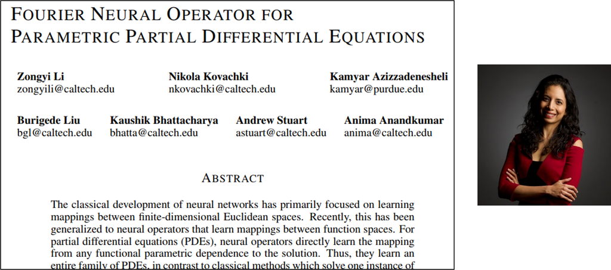

Although both methods offer valuable insights, we focus on DeepONet in this course for the following reasons:

- Intuitive Architecture: DeepONet explicitly separates the input function (branch network) and the operator (trunk network), making it easier to understand and implement.
- Connection to PINNs: DeepONet can be integrated with Physics-Informed Neural Networks (PINNs), making it a natural transition from the previous topics.
- Strong Theoretical Foundations: DeepONet is backed by universal approximation results for operators, making it a powerful tool for learning solution mappings in PDE problems.

By focusing on DeepONet, we can develop a solid foundation for neural operator learning while ensuring applicability to a wide variety of scientific and engineering problems.

# 2. Deep Operator Network (DeepONet)

Consider a flow field in a two-dimensional case. Suppose we are interested in identifying the pressure $P$ at $(y_1, y_2)$ given that the viscosity of the fluid is $\mu_1$. Our goal is to efficiently learn the mapping from viscosity and spatial coordinates to the corresponding pressure field.

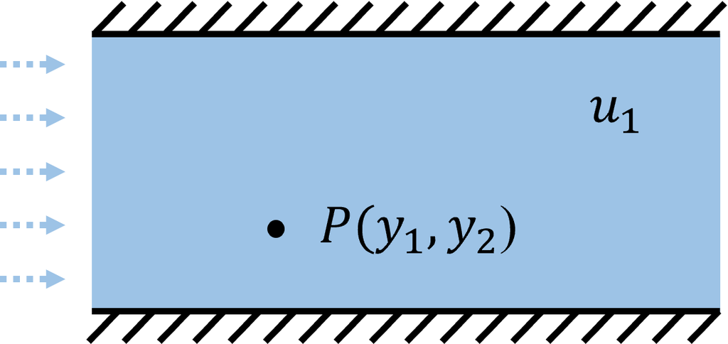

Since it is known that $ \mu_1, y_1, y_2 $ determine the pressure value, a fully connected neural network can serve as a potential candidate for modeling this relationship, where $ \mu_1, y_1, y_2 $ are utilized as input features to predict the corresponding pressure field.

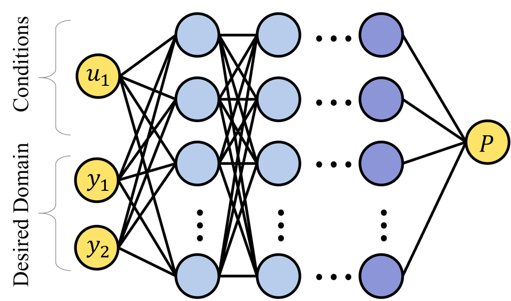

However, it has been observed that the approximation improves when the viscosity $ \mu_1 $ and the spatial coordinates $ (y_1, y_2) $ are processed separately through two distinct neural networks. This approach allows for more effective feature extraction and representation, leading to a better approximation of the pressure field.

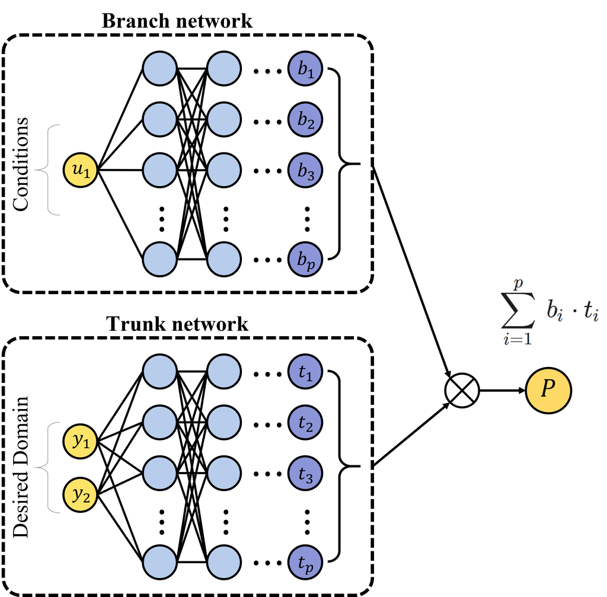

**Training**

To train the two neural networks, it is necessary to obtain solution samples from either a numerical solver or real-world data. These samples are then used to train the model via supervised learning, ensuring that the networks accurately learn the mapping from input conditions to the corresponding pressure field.

**Evaluation**

With an unseen condition $ \mu_1 $, we can sweep across the spatial coordinates $ (y_1, y_2) $ to scan the entire domain and evaluate the corresponding pressure field. This allows us to assess the model's ability to generalize to new conditions and accurately predict pressure distributions across the domain.

In the above example, the viscosity $ \mu_1 $ represents a single condition. However, in many cases, multiple values are required to accurately characterize the conditions. For instance, the inlet velocity distribution can be represented as a vector $ (\mu_1, \mu_2, \cdots, \mu_5) $, capturing variations in flow properties more comprehensively. This multi-dimensional representation allows for a more accurate and generalizable model when predicting the corresponding pressure field.

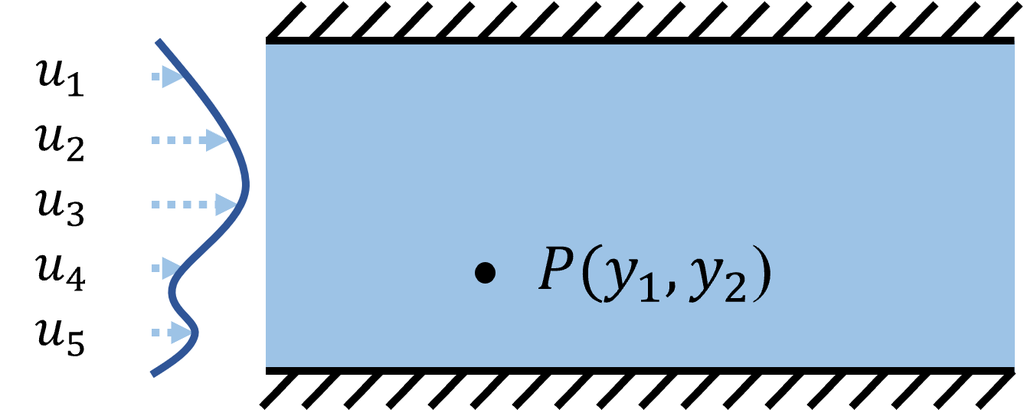

Then, the corresponding neural network should be structured to accommodate multiple input conditions.

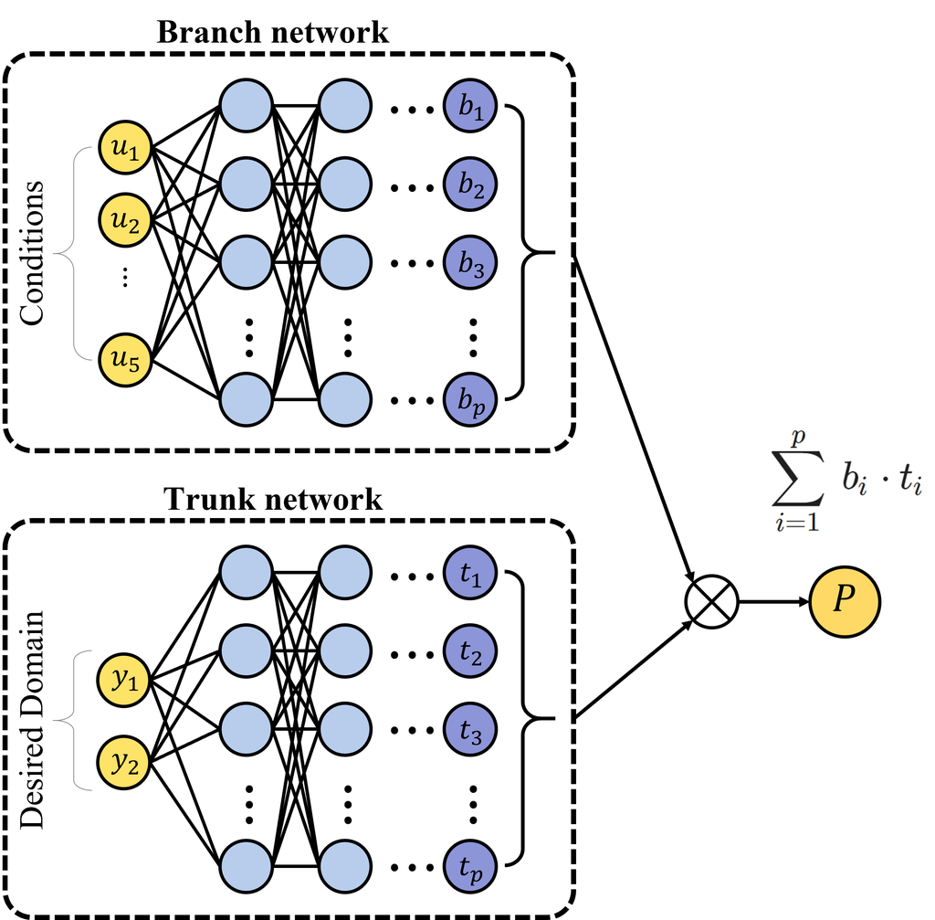

## 2.1. DeepONet Architecture

It is now time to formalize and generalize the DeepONet architecture.

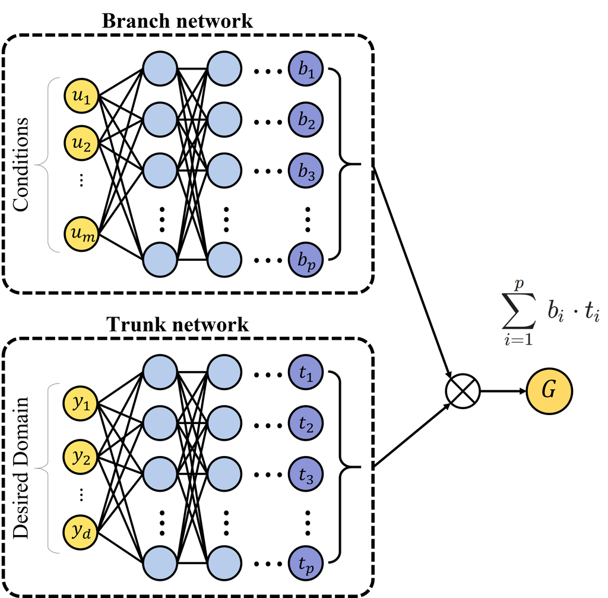

(1) Branch Network

- Encodes the input function values $ (\mu_1, \mu_2, \cdots, \mu_m) $
- e.g., initial/boundary conditions or forcing terms of a PDE
- Outputs a latent representation that captures condition information.

(2) Trunk Network

- Takes spatial or parametric coordinates as inputs $ (y_1, y_2, \cdots, y_d) $.
- Outputs the feature representation of the solution at given locations.

(3) Final Prediction

- The DeepONet learns an operator by combining the outputs of the branch and trunk networks using a dot product:

  $$G(u)(y) = \sum_{i=1}^{p} b_i(u) t_i(y)$$

  where:
  - $G(u)(y)$ is the predicted solution function,
  - $b_i(u)$ are the outputs from the branch network,
  - $t_i(y)$ are the outputs from the trunk network.

This formulation allows DeepONet to approximate operators efficiently.

## 2.2. DeepONet as Basis and Coefficients Representation

DeepONet can be interpreted as a model that learns an operator representation by decomposing the solution function into a set of learned basis functions and their corresponding coefficients. This perspective aligns with classical approximation techniques, such as Fourier and polynomial expansions, where a function is represented as a weighted sum of basis functions.

**Mathematical Interpretation**

Given an operator $ G $ that maps an input function $ u $ to an output function $ G(u) $, DeepONet approximates this mapping as:

$$G(u)(y) = \sum_{i=1}^{p} b_i(u) t_i(y)$$

where:

- $ b_i(u) $ are the coefficients learned from the branch network, which encodes the input function $ u $.
- $ t_i(y) $ are the basis functions learned from the trunk network, which encodes the spatial or parametric coordinates $ y $.
- The final output is obtained through a dot product between the branch and trunk network outputs.

**Comparison with Classical Representations**

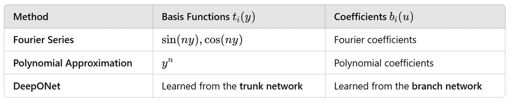

The belwo figure visually represents DeepONet as a basis and coefficients representation, where the framework decomposes the solution into learned coefficients and learned basis functions.

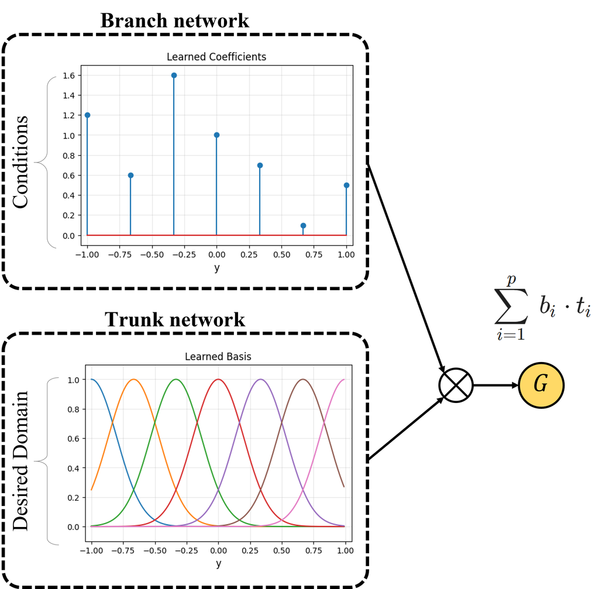

## 2.3. Physics-informed DeepONet (PI-DeepONet)

The DeepONet is fundamentally a data-driven approach, which relies on solution samples obtained from either a numerical solver or real-world data to learn the operator.

In contrast, Physics-Informed DeepONet (PI-DeepONet) enhances the original DeepONet framework by incorporating physical laws directly into the learning process. By embedding governing equations — such as conservation laws or partial differential equations (PDEs) — into the training pipeline, PI-DeepONet effectively leverages both data and physics. This integration leads to improved accuracy, efficiency, and generalization, enabling the model to handle scenarios with sparse or noisy data while maintaining physical consistency.

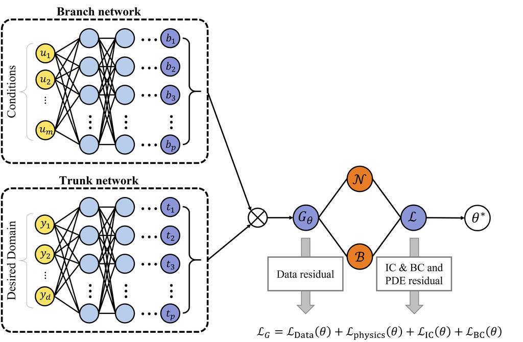

Ideally, Physics-Informed DeepONet (PI-DeepONet) can be trained using only collocation points and governing equations, without requiring any data. However, in practice, it is often recommended to utilize a combination of both observational data and physical laws. This hybrid approach leverages the strengths of data-driven learning and physics-based constraints, leading to improved accuracy, robustness, and generalization, particularly in scenarios where data may be sparse or noisy.

So far, we have explored DeepONet and PI-DeepONet at a high level, covering their fundamental concepts. To gain a solid understanding and practical insights, we will now dive into various examples and applications, illustrating their capabilities and implementation in engineering problems.

# 3. Lab: Heat Transfer in 1D

Consider the simplest example of DeepONet, which consists of:

- One neuron for the branch network (representing the condition).
- One neuron for the trunk network (representing the evaluation location).

This minimal architecture captures the essence of DeepONet while maintaining a lightweight structure.

## 3.1. Problem Setting

Consider the steady-state heat conduction in a 1D rod with boundary conditions:

- Left boundary: $T(0) = 0$
- Right boundary: $T(1) = T_{BC}$

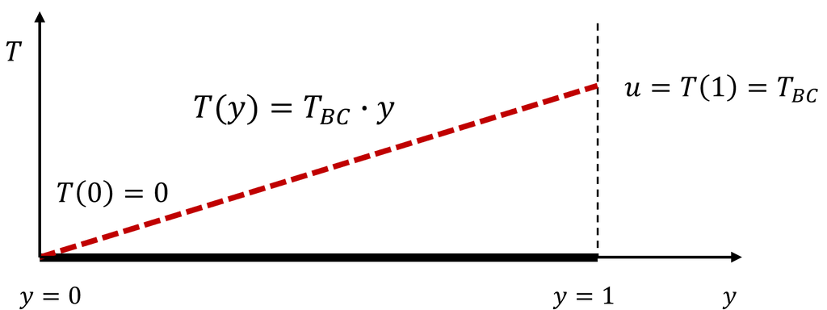

The governing equation for steady-state heat conduction without internal heat generation is:

$$\frac{d^2 T}{dy^2} = 0$$

**Analytical Solution**  
Solving the above equation with the given boundary conditions:

$$T(y) = T_{BC} \cdot y$$

This linear temperature profile represents the heat conduction in a 1D rod.

This example can be used to train a simple DeepONet, where:

- The branch network takes $u = T_{BC}$ as input.
- The trunk network takes $y$ as input.
- The output is $T(y)$, which the model learns from data.

## 3.2. Solve the Heat Transfer 1D Problem using DeepONet

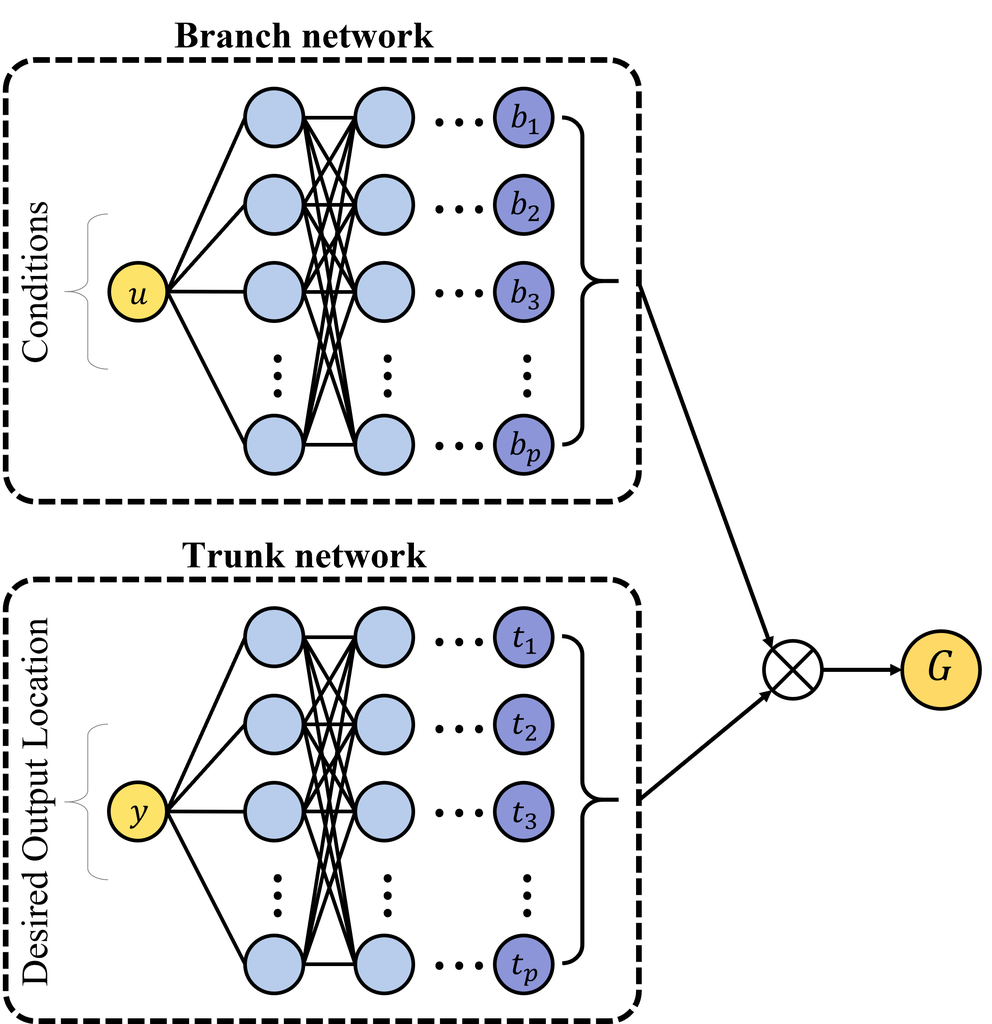

**Import Library**

```python
import numpy as np
import matplotlib.pyplot as plt
import random
import os
import warnings
warnings.filterwarnings("ignore")

import torch
import torch.nn as nn
import torch.optim as optim
from torch.utils import data
%matplotlib inline
```

**CUDA**

```python
device = torch.device('cuda:0' if torch.cuda.is_available() else 'cpu')
print("Using device:", device)
```

```
Using device: cuda:0
```

**Define Desired Ouput Locations**

```python
y_pts = np.linspace(0, 1, 25).reshape(-1, 1)
```

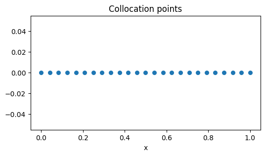

```python
plt.figure(figsize = (6, 3))
y_init = np.zeros(25)
plt.scatter(y_pts, y_init, s = 30)
plt.xlabel('x')
plt.title('Collocation points')
plt.show()
```

**Boundary Condition $u$ and its Ground Truth**

We use 10 points with different $T_{\text{BC}}$ values for training, and one new data point for testing where $T_{\text{BC}} = 60$.

```python
train_q = np.array([10, 20, 30, 40, 50, 70, 80, 90, 100, 110]).reshape(-1, 1)
test_q  = np.array([60]).reshape(-1, 1)
```

```python
train_gt_list = []
for q in train_q:
    train_gt_list.append(q[0] * y_pts.reshape(-1))
train_gt = np.array(train_gt_list)
```

```python
test_gt = 60 * y_pts

print('Loading Conditions for Train: {}'.format(train_q.shape))
print('Ground Truth for Train:       {}'.format(train_gt.shape))
print('Loading Conditions for Test:  {}'.format(test_q.shape))
print('Ground Truth for Test:        {}'.format(test_gt.shape))
```

```
Loading Conditions for Train: (10, 1)
Ground Truth for Train:       (10, 25)
Loading Conditions for Test:  (1, 1)
Ground Truth for Test:        (25, 1)
```

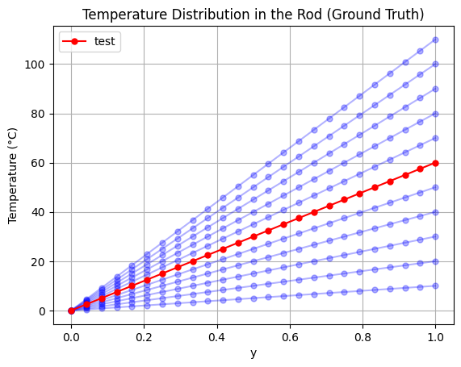

```python
for i in range(10):
  plt.plot(y_pts, train_gt[i], '-o', color = 'b', markersize = 5, alpha = 0.3)

plt.plot(y_pts, test_gt, '-o', color = 'r', markersize = 5, label = 'test')

plt.grid('on')
plt.title('Temperature Distribution in the Rod (Ground Truth)')
plt.legend()
plt.xlabel('y')
plt.ylabel('Temperature (°C)')
plt.show()
```

```python
U = train_q
Y = y_pts
GT = train_gt

print('Conditions:         {}'.format(U.shape))
print('Collocation points: {}'.format(Y.shape))
print('Ground Truths:      {}'.format(GT.shape))
```

```
Conditions:         (10, 1)
Collocation points: (25, 1)
Ground Truths:      (10, 25)
```

**Data Batch Generator**

During the training of DeepONet, data needs to be provided in batches. A Data Batch Generator efficiently feeds training data into the DeepONet model.

```python
class DataGenerator(data.Dataset):
    def __init__(self, u, y, gt, batch_size = 64):
        self.u = torch.tensor(u, dtype = torch.float32)
        self.y = torch.tensor(y, dtype = torch.float32)
        self.gt = torch.tensor(gt, dtype = torch.float32)
        self.N = self.u.shape[0] * self.y.shape[0]
        self.batch_size = batch_size

    def __len__(self):
        return (self.N // self.batch_size) + 1

    def __getitem__(self, index):
        u_idx = torch.randint(low = 0, high=self.u.shape[0], size = (self.batch_size,))
        y_idx = torch.randint(low = 0, high=self.y.shape[0], size = (self.batch_size,))
        u_sample = self.u[u_idx, :]
        y_sample = self.y[y_idx, :]
        gt_sample = self.gt[u_idx, y_idx].reshape(-1, 1)
        return u_sample, y_sample, gt_sample

train_dataset = DataGenerator(U, Y, GT)
```

**Define DeepONet**

We first define BranchNet and TrunkNet, and then combine them to build the full DeepONet model.

- BranchNet extracts features from the input function (e.g., discretized loading conditions).
- TrunkNet extracts features from spatial locations where predictions are required.
- The final DeepONet combines them via a dot product to generate the output.

```python
class BranchNet(nn.Module):
    def __init__(self, input_dim = 1):
        super(BranchNet, self).__init__()
        self.linears = nn.Sequential(
            nn.Linear(input_dim, 32),
            nn.Tanh(),
            nn.Linear(32, 32),
            nn.Tanh(),
            nn.Linear(32, 32),
            nn.Tanh(),
            nn.Linear(32, 32),
            nn.Tanh(),
            nn.Linear(32, 16)
        )

    def forward(self, x):
        return self.linears(x.float())

class TrunkNet(nn.Module):
    def __init__(self, input_dim = 1):
        super(TrunkNet, self).__init__()
        self.linears = nn.Sequential(
            nn.Linear(input_dim, 32),
            nn.Tanh(),
            nn.Linear(32, 32),
            nn.Tanh(),
            nn.Linear(32, 32),
            nn.Tanh(),
            nn.Linear(32, 32),
            nn.Tanh(),
            nn.Linear(32, 16)
        )

    def forward(self, x):
        return self.linears(x.float())

class DeepONet(nn.Module):
    def __init__(self):
        super(DeepONet, self).__init__()
        self.branch_net = BranchNet(input_dim = 1)
        self.trunk_net = TrunkNet(input_dim = 1)

    def forward(self, u, y):
        branch_out = self.branch_net(u)
        trunk_out = self.trunk_net(y)
        out = torch.sum(branch_out * trunk_out, dim = 1).reshape(-1, 1)
        return out

model = DeepONet().to(device)

optimizer = optim.Adam(model.parameters(), lr = 5e-4)
Loss_func = nn.MSELoss(reduction = 'mean')
```

**Train**

```python
train_iter = iter(train_dataset)
epoch = 0
model.train()

while epoch < 2001:
    u_batch, y_batch, gt_batch = next(train_iter)

    u_batch = u_batch.to(device)
    y_batch = y_batch.to(device)
    gt_batch = gt_batch.to(device)

    pred = model(u_batch, y_batch)
    loss = Loss_func(pred.float(), gt_batch.float())

    optimizer.zero_grad()
    loss.backward()
    optimizer.step()

    if epoch % 500 == 0:
        with torch.no_grad():
            print('Epoch: {} Loss: {:.6f}'.format(epoch, loss.item()))
    epoch += 1
```

```
Epoch: 0 Loss: 1191.148438
Epoch: 500 Loss: 2.507274
Epoch: 1000 Loss: 0.624888
Epoch: 1500 Loss: 0.180778
Epoch: 2000 Loss: 0.104491
```

**Evaluation**

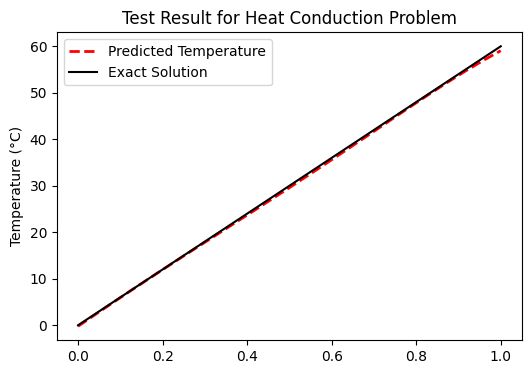

```python
def exact_solution(x):
    return 60 * x

with torch.no_grad():
    model.eval()
    test_u = torch.tensor(test_q, dtype = torch.float32).to(device)
    test_Y = torch.tensor(y_pts, dtype = torch.float32).to(device)

    preds = []
    for y in test_Y:
        y_input = y.reshape(-1, 1)
        pred = model(test_u, y_input)
        preds.append(pred)

    test_pred = torch.cat(preds, dim = 0)

    plt.figure(figsize = (6, 4))
    plt.plot(y_pts, test_pred.detach().cpu().numpy(), c = 'r', label = 'Predicted Temperature',
             linestyle = 'dashed', linewidth = 2)
    plt.plot(y_pts, exact_solution(y_pts), c = 'k', label = 'Exact Solution')
    plt.legend(fontsize = 10)
    plt.xticks(fontsize = 10)
    plt.yticks(fontsize = 10)
    plt.ylabel('Temperature (°C)')
    plt.title('Test Result for Heat Conduction Problem')
    plt.show()
```

# 4. Lab: Euler Beam

## 4.1. Problem Setup

- We will solve a Euler beam bending problem using DeepONet:

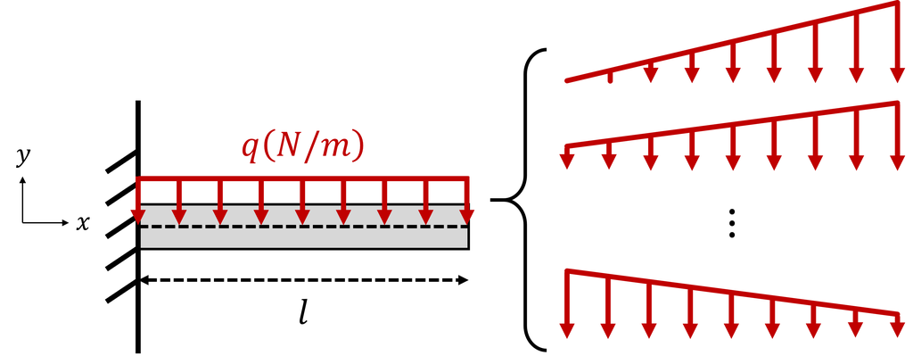

- Problem properties

$$E = 1 \operatorname{pa}, \quad I = 1 \operatorname{kg\cdot m^2}, \quad l = 1 \operatorname{m}$$

- Training dataset consists of 10 different loading conditions
- The load distribution $q(x)$ is represented using 20 equally spaced points, denoted as $u_1, u_2, \cdots, u_{20}$.
- The external loading $q(x)$ can be arbitrarily distributed. However, for simplicity, we limit ourselves to the case where $q(x)$ follows an affine form:

  $$ q(x) = \omega x + \omega_0 $$
  where $\omega$ and $\omega_0$ are constants.
- The exact solution can be easily calcuated. For example, when $q (x) = 1$

$$y(x) = -{1 \over 24}x^4 + {1 \over 6}x^3 - {1 \over 4}x^2$$

- Assume that the desired output locations are set to be 25 equally spaced evaluation points in $[0, 1]$

## 4.2. Solve the Euler Beam Problem with DeepONet

- The corresponding DeepONet structure is as follows.

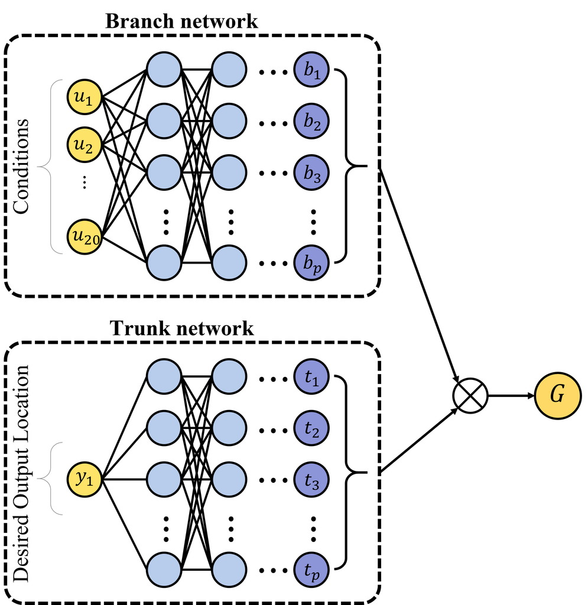

```python
from google.colab import drive
drive.mount('/content/drive')
```

**Import Library**

```python
import numpy as np
import random
import matplotlib.pyplot as plt
%matplotlib inline

import torch
import torch.nn as nn
import torch.optim as optim
from torch.utils import data

import warnings
warnings.filterwarnings("ignore")
```

**CUDA**

```python
device = torch.device('cuda:0' if torch.cuda.is_available() else 'cpu')
print(device)
```

```
cuda:0
```

**Define Desired Ouput Locations**

```python
# Desired ouput locations

y_pts = np.linspace(0, 1, 25).reshape(-1, 1)
```

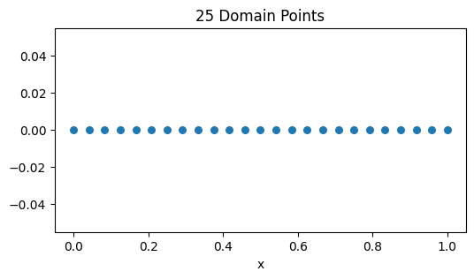

```python
plt.figure(figsize = (6, 3))
plt.scatter(y_pts, np.zeros(25), s = 30)
plt.xlabel('x')
plt.title('25 Domain Points')
plt.show()
```

**Load $q(x)$ and its Ground Truth**

We use 10 distributed loads with varying $\omega_0$ and $\omega_1$ for training, and one distributed load for testing, $q(x) = 1$.

Download

- [q_train](https://drive.google.com/file/d/15uCCRPb3q867OiBas3UO52QoAohVIkXh/view?usp=sharing)
- [q_test](https://drive.google.com/file/d/1JlL2IIElYaSMcwOjtYpHsL1uA8FhFGFT/view?usp=sharing)
- [gt_train](https://drive.google.com/file/d/1GbZnk1UeU5mzxX2ayHsqlayvs2r7Cdnr/view?usp=sharing)
- [gt_test](https://drive.google.com/file/d/13lpteeTv74QVJ6QXe5AkiyaBTvsKTr-Y/view?usp=sharing)

```python
train_q =  np.load('/content/drive/MyDrive/DL/DL_data/q_train.npy')
test_q = np.load('/content/drive/MyDrive/DL/DL_data/q_test.npy')
train_gt = np.load('/content/drive/MyDrive/DL/DL_data/gt_train.npy')
test_gt = np.load('/content/drive/MyDrive/DL/DL_data/gt_test.npy')

print('Loading Condtions for Train  :{}'.format(train_q.shape))
print('Ground Truth for Train       :{}\n'.format(train_gt.shape))

print('Loading Condtions for Test   :{}'.format(test_q.shape))
print('Ground Truth for Test        :{}'.format(test_gt.shape))
```

```
Loading Condtions for Train  :(10, 20)
Ground Truth for Train       :(10, 25)

Loading Condtions for Test   :(1, 20)
Ground Truth for Test        :(1, 25)
```

**External Load $q(x)$**

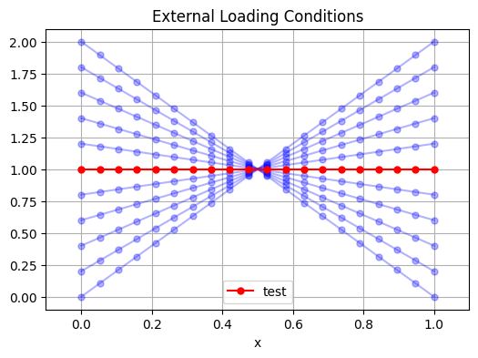

```python
x_pts = np.linspace(0, 1, 20)

plt.figure(figsize=(6, 4))

for i in range(10):
  plt.plot(x_pts, train_q[i], '-o', color = 'b', markersize = 5, alpha = 0.3)

plt.plot(x_pts, test_q[0], '-o', color = 'r', markersize = 5, label = 'test')

plt.grid('on')
plt.xlim([-0.1, 1.1])
plt.ylim([-0.1, 2.1])
plt.title('External Loading Conditions')
plt.legend()
plt.xlabel('x')
plt.show()
```

**Corresponding Ground Truth for Bending Displacement**

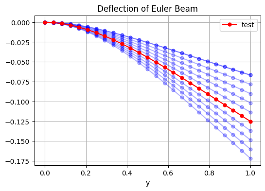

```python
plt.figure(figsize = (6, 4))

for i in range(10):
  plt.plot(y_pts, train_gt[i], '-o', color = 'b', markersize = 5, alpha = 0.3)

plt.plot(y_pts, test_gt[0], '-o', color = 'r', markersize = 5, label = 'test')

plt.title("Deflection of Euler Beam")
plt.legend()
plt.grid('on')
plt.xlabel('y')
plt.show()
```

**Data Batch Generator**

During the training of DeepONet, data needs to be provided in batches. A Data Batch Generator efficiently feeds training data into the DeepONet model.

```python
U = train_q
Y = y_pts
GT = train_gt

print('Loading conditions :{}'.format(U.shape))
print('desired output locs:{}'.format(Y.shape))
print('Ground truths      :{}'.format(GT.shape))
```

```
Loading conditions :(10, 20)
desired output locs:(25, 1)
Ground truths      :(10, 25)
```

```python
# Data Batch Generator
class DataGenerator(data.Dataset):
    def __init__(self, u, y, gt, batch_size = 64):
        'Initialization'
        self.u = torch.tensor(u, dtype = torch.float32)
        self.y = torch.tensor(y, dtype = torch.float32)
        self.gt = torch.tensor(gt, dtype = torch.float32)
        self.N = self.u.shape[0] * self.y.shape[0]
        self.batch_size = batch_size

    def __len__(self):
        return (self.N // self.batch_size) + 1

    def __getitem__(self, index):
        u_idx = torch.randint(low = 0, high = self.u.shape[0], size = (self.batch_size,))
        y_idx = torch.randint(low = 0, high = self.y.shape[0], size = (self.batch_size,))
        u = self.u[u_idx, :]
        y = self.y[y_idx, :]
        gt = self.gt[u_idx, y_idx].reshape(-1, 1)
        return u, y, gt
```

```python
train_dataset = DataGenerator(U, Y, GT)
```

**Define DeepONet**

We first define BranchNet and TrunkNet, and then combine them to build the full DeepONet model.

- BranchNet extracts features from the input function (e.g., discretized loading conditions).
- TrunkNet extracts features from spatial locations where predictions are required.
- The final DeepONet combines them via a dot product to generate the output.

```python
class BranchNet(nn.Module):
    def __init__(self, input_dim = 20):
        super(BranchNet, self).__init__()
        self.linears = nn.Sequential(
            nn.Linear(input_dim, 32),
            nn.Tanh(),
            nn.Linear(32, 32),
            nn.Tanh(),
            nn.Linear(32, 32),
            nn.Tanh(),
            nn.Linear(32, 32),
            nn.Tanh(),
            nn.Linear(32, 16)
        )

    def forward(self, x):
        a = x.float()
        return self.linears(a)


class TrunkNet(nn.Module):
    def __init__(self, input_dim = 1):
        super(TrunkNet, self).__init__()
        self.linears = nn.Sequential(
            nn.Linear(input_dim, 32),
            nn.Tanh(),
            nn.Linear(32, 32),
            nn.Tanh(),
            nn.Linear(32, 32),
            nn.Tanh(),
            nn.Linear(32, 32),
            nn.Tanh(),
            nn.Linear(32, 16)
        )

    def forward(self, x):
        a = x.float()
        return self.linears(a)

class DeepONet(nn.Module):
    def __init__(self):
        super(DeepONet, self).__init__()
        self.branch_net = BranchNet(input_dim = 20)
        self.trunk_net = TrunkNet(input_dim = 1)

    def forward(self, u, y):
        branch_out = self.branch_net(u)
        trunk_out = self.trunk_net(y)
        out = torch.sum(branch_out * trunk_out, dim = 1).reshape(-1,1)
        return out
```

```python
model = DeepONet().to(device)

optimizer = optim.Adam(model.parameters(), lr = 5e-4)
Loss_func = nn.MSELoss(reduction = 'mean')
```

**Train**

```python
train_iter = iter(train_dataset)
epoch = 0

model.train()

while epoch < 2001:
  train_batch = next(train_iter)
  u_batch, y_batch, gt_batch = train_batch

  u_batch = u_batch.to(device)
  y_batch = y_batch.to(device)
  gt_batch = gt_batch.to(device)

  pred = model(u_batch, y_batch)

  loss = Loss_func(pred.float(), gt_batch.float())

  optimizer.zero_grad()
  loss.backward()
  optimizer.step()

  if epoch % 500 == 0:
      with torch.no_grad():
          print('Epoch: {:4d} Loss: {:.6f} '.format(epoch, loss.item()))

  epoch += 1
```

```
Epoch:    0 Loss: 0.010216
Epoch:  500 Loss: 0.000089
Epoch: 1000 Loss: 0.000115
Epoch: 1500 Loss: 0.000013
Epoch: 2000 Loss: 0.000005
```

**Evaluation**

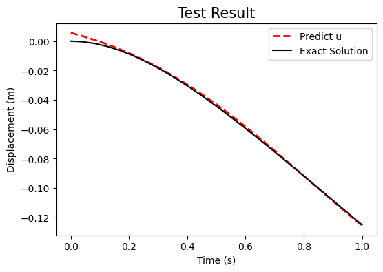

```python
def exact_solution(x):
    return -(x ** 4) / 24 + x ** 3 / 6 - x ** 2 / 4

with torch.no_grad():
    model.eval()

    test_u = torch.tensor(test_q, dtype = torch.float32).to(device)
    test_Y = torch.tensor(y_pts, dtype = torch.float32).to(device)

    preds = []
    for y in test_Y:
      pred = model(test_u, y)
      preds.append(pred)

    test_pred = torch.cat(preds, dim = 0)

# plot
    plt.figure(figsize = (6, 4))
    plt.plot(y_pts, test_pred.detach().cpu().numpy(), c =  'r',
             label = 'Predict u', linestyle = 'dashed', linewidth = 2)
    plt.plot(y_pts, exact_solution(y_pts), c =  'k', label = 'Exact Solution')
    plt.legend(fontsize = 10)
    plt.xticks(fontsize = 10)
    plt.yticks(fontsize = 10)
    plt.xlabel('Time (s)', fontsize = 10)
    plt.ylabel('Displacement (m)', fontsize = 10)
    plt.title('Test Result', fontsize = 15)
    plt.show()
```

# 5. Lab: Flow Around a Cylinder

So far, we have demonstrated how to implement DeepONet with two simple examples. If physics is available, we can incorporate physical laws into DeepONet, resulting in **PI-DeepONet** (Physics-Informed DeepONet). Essentially, this approach combines PINNs with DeepONet, allowing the model to learn from both data and governing physical equations.

We will learn how to implement PI-DeepONet with the following example: Flow around a cylinder.

## 5.1. Problem Setup

- We will solve the Naiver-Stokes equation with varying viscosity term with PI-DeepONet
  - Data from a numerial solver and
  - Physics (PDE and BC)

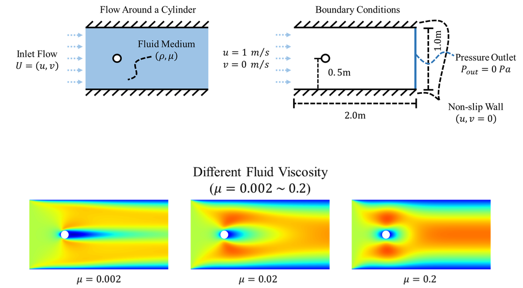

- Problem properties

- 2D Navier-Stokes Equations & boundary conditions (for steady state)

$$ \begin{align*} \rho \left(u{\partial u \over \partial x} + v{\partial u \over \partial y} + {1 \over \rho}{\partial p \over \partial x}\right) - \mu \ \left({\partial^2 u \over {\partial x^2}} + {\partial^2 u \over {\partial y^2}}\right) &= 0\\\\ \rho \left(u{\partial v \over \partial x} + v{\partial v \over \partial y} + {1 \over \rho}{\partial p \over \partial y}\right) - \mu \ \left({\partial^2 v \over {\partial x^2}} + {\partial^2 v \over {\partial y^2}}\right) &= 0\\\\ {\partial u \over \partial x} + {\partial v \over \partial y} &= 0 \end{align*} $$

- Two Dirichlet boundary conditions on the plate boundary (no-slip condition)

$$u(x,y) = 0, \quad v(x,y) = 0 \qquad \text{at} \quad y = \frac{D}{2} \ \; \text{or} \; -\frac{D}{2}$$

$$u(-1,y) = u_{\text{in}}, \quad v(-1,y) = 0$$

- Two Dirichlet boundary conditions at the outlet boundary

$$p(1,y) = 0, \quad v(1,y) = 0$$

- Two Dirichlet boundary conditions at the cylinder boundary

$$u(\text{cylinder}) = 0, \quad v(\text{cylinder}) = 0$$

- Create a neural network and define loss functions as follows:
  - A single input neuron for the branch network
  - Two input neurons for the trunk network

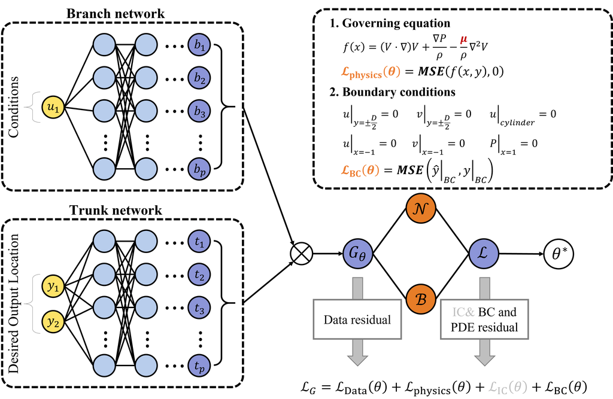

```python
from google.colab import drive
drive.mount('/content/drive')
```

## 5.2. Solve the Navier-Stokes Equations with PI-DeepONet

**Load Library**

```python
import numpy as np
import matplotlib.pyplot as plt
import random
import torch
import torch.nn as nn
import torch.optim as optim
from torch.utils import data

%matplotlib inline

import os
import warnings
warnings.filterwarnings("ignore")
```

**CUDA**

```python
device = torch.device('cuda:0' if torch.cuda.is_available() else 'cpu')
print(device)
```

```
cuda:0
```

**Define Conditions**

- Train: 9 different viscosity values
- Test: 2 unseen viscosity values

```python
train_vis = np.array([0.002, 0.004, 0.008, 0.01, 0.02, 0.06, 0.08, 0.1, 0.2]).reshape(-1, 1)
test_vis = np.array([0.006, 0.04]).reshape(-1, 1)
```

To obtain the ground truth for the training data, a CFD simulation has been performed. The ground truth values are stored only at the mesh points in the CFD simulation.

Download

- [train_xy_domain](https://www.dropbox.com/scl/fi/j8eglfmpa70n6c8qpepc1/viscosity_train_xy_domain.npy?rlkey=vvyda3ifg3r1svedztdyjcyhc&st=itlfievu&dl=1)
- [train_gt_domain](https://www.dropbox.com/scl/fi/exuohui5v2aegxr28d0s5/viscosity_train_gt_domain.npy?rlkey=nmmtku3putcxzfztt0wtbh1dx&st=1ku80lo3&dl=1)
- [test_xy_domain](https://www.dropbox.com/scl/fi/33dxnjg8tjfbw1xkw3wsv/viscosity_test_xy_domain.npy?rlkey=yjeju6ahk8ar3ttqg6wrt3eit&st=dnkpp6up&dl=1)
- [test_gt_domain](https://www.dropbox.com/scl/fi/aafhji51uampa74eo89a7/viscosity_test_gt_domain.npy?rlkey=8hsj1ui8t1pc3c3jj4m296x4t&st=w7iejhkp&dl=1)

```python
mesh_pts = np.load('/content/drive/MyDrive/DL/DL_data/viscosity_train_xy_domain.npy')
train_gt= np.load('/content/drive/MyDrive/DL/DL_data/viscosity_train_gt_domain.npy')
test_gt = np.load('/content/drive/MyDrive/DL/DL_data/viscosity_test_gt_domain.npy')
```

```python
print("train XY shape: {}".format(mesh_pts[0].shape))
print("train gt shape: {}".format(train_gt.shape))
print("test gt shape:  {}".format(test_gt.shape))
```

```
train XY shape: (19692, 2)
train gt shape: (9, 19692, 3)
test gt shape:  (2, 19692, 3)
```

Note

- 19,692 mesh points
- $(y_1, y_2)$ (or $(x,y)$) are the desired output locations
- For each mesh point, the output values include:
  - velocity in the $x$ direction
  - velocity in the $y$ direction
  - pressure

**Collocation Points for PDE (Desired Output Locations)**

All the mesh points in the CFD simulation are good candidates for collocation points in PI-DeepONet. These points ensure that the model adheres to physics-informed constraints.

```python
y_pts = mesh_pts[0]
```

**Collocation Points for Boundary Conditions**

```python
top_x = np.linspace(-0.5, 1.5, 200).reshape(-1, 1)
top_y = 0.5 * np.ones_like(top_x).reshape(-1, 1)

bottom_x = np.linspace(-0.5, 1.5, 200).reshape(-1, 1)
bottom_y = -0.5 * np.ones_like(bottom_x).reshape(-1, 1)

inlet_y = np.linspace(-0.5, 0.5, 100).reshape(-1, 1)
inlet_x = -0.5 * np.ones_like(inlet_y).reshape(-1, 1)

outlet_y = np.linspace(-0.5, 0.5, 100).reshape(-1, 1)
outlet_x = 1.5 * np.ones_like(outlet_y).reshape(-1, 1)

radius = 0.05
theta = np.linspace(0, 2 * np.pi, 200)
cylinder_x = (0 + radius * np.cos(theta)).reshape(-1, 1)
cylinder_y = (0 + radius * np.sin(theta)).reshape(-1, 1)

top_pts = np.hstack((top_x, top_y))
bottom_pts = np.hstack((bottom_x, bottom_y))
inlet_pts = np.hstack((inlet_x, inlet_y))
outlet_pts = np.hstack((outlet_x, outlet_y))
cylinder_pts = np.hstack((cylinder_x, cylinder_y))

wall_pts = np.concatenate((top_pts, bottom_pts, cylinder_pts), 0)
```

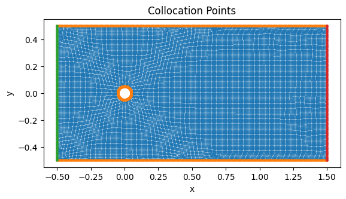

```python
plt.scatter(y_pts[:, 0], y_pts[:, 1], s = 1)
plt.scatter(wall_pts[:, 0], wall_pts[:, 1], s = 5)
plt.scatter(inlet_pts[:, 0], inlet_pts[:, 1], s = 5)
plt.scatter(outlet_pts[:, 0], outlet_pts[:, 1], s = 5)

plt.title('Collocation Points')
plt.axis('scaled')
plt.xlabel('x')
plt.ylabel('y')
plt.show()
```

**Data Batch Generator**

```python
U = train_vis
Y = y_pts
GT = train_gt

print('Loading conditions :{}'.format(U.shape))
print('desired output locs:{}'.format(Y.shape))
print('Ground truths      :{}'.format(GT.shape))

U_test = test_vis
Y_test = y_pts
GT_test = test_gt

Y_wall = wall_pts
Y_inlet = inlet_pts
Y_outlet = outlet_pts
```

```
Loading conditions :(9, 1)
desired output locs:(19692, 2)
Ground truths      :(9, 19692, 3)
```

```python
# Data generator
class DataGenerator(data.Dataset):
    def __init__(self, u, y, gt, batch_size = 64):
        'Initialization'
        self.u = torch.tensor(u, dtype = torch.float32)
        self.y = torch.tensor(y, dtype = torch.float32)
        self.gt = torch.tensor(gt, dtype = torch.float32)
        self.N = self.u.shape[0] * self.y.shape[0]
        self.batch_size = batch_size

    def __len__(self):
        return (self.N // self.batch_size) + 1

    def __getitem__(self,index):
        u_idx = torch.randint(low = 0, high = self.u.shape[0], size = (self.batch_size,))
        y_idx = torch.randint(low = 0, high = self.y.shape[0], size = (self.batch_size,))
        u = self.u[u_idx, :]
        y = self.y[y_idx, :]
        gt = self.gt[u_idx, y_idx, :]
        return u, y, gt

# BC generator
class BCGenerator(data.Dataset):
    def __init__(self, u, y, batch_size = 64):
        'Initialization'
        self.u = torch.tensor(u, dtype = torch.float32)
        self.y = torch.tensor(y, dtype = torch.float32)
        self.N = self.u.shape[0] * self.y.shape[0]
        self.batch_size = batch_size

    def __len__(self):
        return (self.N // self.batch_size) + 1

    def __getitem__(self,index):
        u_idx = torch.randint(low = 0, high = self.u.shape[0], size = (self.batch_size,))
        y_idx = torch.randint(low = 0, high = self.y.shape[0], size = (self.batch_size,))
        u = self.u[u_idx, :]
        y = self.y[y_idx, :]
        return u, y
```

```python
train_dataset = DataGenerator(U, Y, GT)
train_inlet = BCGenerator(U, Y_inlet)
train_wall = BCGenerator(U, Y_wall)
train_outlet = BCGenerator(U, Y_outlet)
```

**Define DeepONet Structure**

```python
class BranchNet(nn.Module):
    def __init__(self, input_dim = 1):
        super(BranchNet, self).__init__()
        self.linears = nn.Sequential(
            nn.Linear(input_dim, 100),
            nn.Tanh(),
            nn.Linear(100, 100),
            nn.Tanh(),
            nn.Linear(100, 100),
            nn.Tanh(),
            nn.Linear(100, 100),
            nn.Tanh(),
            nn.Linear(100, 100),
            nn.Tanh(),
            nn.Linear(100, 100),
            nn.Tanh(),
            nn.Linear(100, 100)
        )

    def forward(self, x):
        a = x.float()
        return self.linears(a)

class TrunkNet(nn.Module):
    def __init__(self, input_dim = 2):
        super(TrunkNet, self).__init__()
        self.linears = nn.Sequential(
            nn.Linear(input_dim, 100),
            nn.Tanh(),
            nn.Linear(100, 100),
            nn.Tanh(),
            nn.Linear(100, 100),
            nn.Tanh(),
            nn.Linear(100, 100),
            nn.Tanh(),
            nn.Linear(100, 100),
            nn.Tanh(),
            nn.Linear(100, 100),
            nn.Tanh(),
            nn.Linear(100, 100)
        )

    def forward(self, x):
        a = x.float()
        return self.linears(a)

class DeepONet(nn.Module):
    def __init__(self):
        super(DeepONet, self).__init__()
        self.branch_net = BranchNet(input_dim = 1 )
        self.trunk_net = TrunkNet(input_dim = 2)

    def forward(self, u, y):
        branch_out = self.branch_net(u)
        trunk_out = self.trunk_net(y)
        out = torch.sum(branch_out * trunk_out, dim = 1).reshape(-1,1)
        return out
```

Since the output includes velocities in the $x$- and $y$-directions and pressure, three separate DeepONets are built - one for each output.

We could have designed a single DeepONet with three output neurons, but to keep the network as simple as possible, we chose to build three independent networks instead.

```python
model_v1 = DeepONet().to(device)
model_v2 = DeepONet().to(device)
model_p = DeepONet().to(device)

optimizer = optim.Adam(list(model_v1.parameters()) +
                       list(model_v2.parameters()) +
                       list(model_p.parameters()),
                       lr = 5e-4)

Loss_func = nn.MSELoss(reduction = 'mean')
```

**Define Functions to Compute Physics Loss**

```python
def derivative(y, t) :
    df = torch.autograd.grad(y, t, create_graph = True, retain_graph = True,
                             grad_outputs = torch.ones(y.size()).to(device))[0]
    df_x = df[:, 0:1]
    df_y = df[:, 1:2]
    return df_x, df_y

def requires_grad(x):
    return torch.tensor(x, requires_grad = True).to(device)
```

**Define PDE**

- 2D Navier-Stokes Equations & boundary conditions (for steady state)

$$ \begin{align*} \rho \left(u{\partial u \over \partial x} + v{\partial u \over \partial y} + {1 \over \rho}{\partial p \over \partial x}\right) - \mu \ \left({\partial^2 u \over {\partial x^2}} + {\partial^2 u \over {\partial y^2}}\right) &= 0\\\\ \rho \left(u{\partial v \over \partial x} + v{\partial v \over \partial y} + {1 \over \rho}{\partial p \over \partial y}\right) - \mu \ \left({\partial^2 v \over {\partial x^2}} + {\partial^2 v \over {\partial y^2}}\right) &= 0\\\\ {\partial u \over \partial x} + {\partial v \over \partial y} &= 0 \end{align*} $$

```python
def PDE(u_batch, y_batch):

    v1, v2, p = model_v1(u_batch, y_batch), model_v2(u_batch, y_batch), model_p(u_batch, y_batch)

    dv1_x, dv1_y = derivative(v1, y_batch)
    dv1_xx, _ = derivative(dv1_x, y_batch)
    _, dv1_yy =  derivative(dv1_y, y_batch)

    dv2_x, dv2_y = derivative(v2, y_batch)
    dv2_xx, _ = derivative(dv2_x, y_batch)
    _, dv2_yy = derivative(dv2_y, y_batch)

    dp_x, dp_y = derivative(p, y_batch)

    vis = u_batch
    pde_v1 = 1 * (v1 * dv1_x + v2 * dv1_y) + dp_x - vis * (dv1_xx + dv1_yy)
    pde_v2 = 1 * (v1 * dv2_x + v2 * dv2_y) + dp_y - vis * (dv2_xx + dv2_yy)
    pde_cont = dv1_x + dv2_y

    return pde_v1.float(), pde_v2.float(), pde_cont.float()
```

**Boundary Conditions**

- Two Dirichlet boundary conditions on the plate boundary (no-slip condition),

$$u(x,y) = 0, \quad v(x,y) = 0 \qquad \text{at} \quad y = \frac{D}{2} \ \; \text{or} \; -\frac{D}{2}$$

- Two Dirichlet boundary conditions at the cylinder boundary

$$u(\text{cylinder}) = 0, \quad v(\text{cylinder}) = 0$$

- Two Dirichlet boundary conditions at the inlet boundary

$$u(-1,y) = u_{\text{in}}, \quad v(-1,y) = 0$$

- Two Dirichlet boundary conditions at the outlet boundary

$$p(1,y) = 0, \quad v(1,y) = 0$$

```python
def BC_wall(u_wall, y_wall):
    wall_v1 = model_v1(u_wall, y_wall)
    wall_v2 = model_v2(u_wall, y_wall)
    return wall_v1.float(), wall_v2.float()

def BC_inlet(u_inlet, y_inlet):
    inlet_v1 = model_v1(u_inlet, y_inlet)
    inlet_v1 = inlet_v1 - torch.ones_like(inlet_v1).to(device)
    inlet_v2 = model_v2(u_inlet, y_inlet)
    return inlet_v1.float(), inlet_v2.float()

def BC_outlet(u_outlet, y_outlet):
    outlet_v2 = model_v2(u_outlet, y_outlet)
    outlet_p = model_p(u_outlet, y_outlet)
    return outlet_v2.float(), outlet_p.float()
```

**Train**

```python
epoch = 0

train_iter = iter(train_dataset)
train_wall_iter = iter(train_wall)
train_inlet_iter = iter(train_inlet)
train_outlet_iter = iter(train_outlet)

while epoch < 150001:

    train_batch = next(train_iter)
    train_wall_batch = next(train_wall_iter)
    train_inlet_batch = next(train_inlet_iter)
    train_outlet_batch = next(train_outlet_iter)

    u_batch, y_batch, gt_batch = train_batch
    u_wall_batch, y_wall_batch = train_wall_batch
    u_inlet_batch, y_inlet_batch = train_inlet_batch
    u_outlet_batch, y_outlet_batch = train_outlet_batch

    ## Reguires grad
    u_batch, y_batch, gt_batch = requires_grad(u_batch), requires_grad(y_batch), requires_grad(gt_batch)
    u_wall_batch, y_wall_batch = requires_grad(u_wall_batch), requires_grad(y_wall_batch) # BC wall
    u_inlet_batch, y_inlet_batch = requires_grad(u_inlet_batch), requires_grad(y_inlet_batch) # BC inlet
    u_outlet_batch, y_outlet_batch = requires_grad(u_outlet_batch), requires_grad(y_outlet_batch) # BC outlet

    v1, v2, p = model_v1(u_batch, y_batch), model_v2(u_batch, y_batch), model_p(u_batch, y_batch)

    ## Data loss
    loss_data_v1 = Loss_func(v1.float(), gt_batch[:, 0:1].float())
    loss_data_v2 = Loss_func(v2.float(), gt_batch[:, 1:2].float())
    loss_data_p = Loss_func(p.float(), gt_batch[:, 2:3].float())

    loss_data = loss_data_v1 + loss_data_v2 + loss_data_p

    ## PDE loss
    PDE_v1, PDE_v2, PDE_cont = PDE(u_batch, y_batch)

    loss_PDE_v1 = Loss_func(PDE_v1, torch.zeros_like(PDE_v1).to(device))
    loss_PDE_v2 = Loss_func(PDE_v2, torch.zeros_like(PDE_v2).to(device))
    loss_PDE_cont = Loss_func(PDE_cont, torch.zeros_like(PDE_cont).to(device))

    loss_pde = loss_PDE_v1 + loss_PDE_v2 + loss_PDE_cont

    ## BC loss
    wall_v1, wall_v2 = BC_wall(u_wall_batch, y_wall_batch)
    inlet_v1, inlet_v2 = BC_inlet(u_inlet_batch, y_inlet_batch)
    outlet_v2, outlet_p = BC_outlet(u_outlet_batch, y_outlet_batch)

    loss_BC_wall_v1 = Loss_func(wall_v1, torch.zeros_like(wall_v1).to(device))
    loss_BC_wall_v2 = Loss_func(wall_v2, torch.zeros_like(wall_v2).to(device))
    loss_BC_inlet_v1 = Loss_func(inlet_v1, torch.zeros_like(inlet_v1).to(device))
    loss_BC_inlet_v2 = Loss_func(inlet_v2, torch.zeros_like(inlet_v2).to(device))
    loss_BC_outlet_v2 = Loss_func(outlet_v2, torch.zeros_like(outlet_v2).to(device))
    loss_BC_outlet_p = Loss_func(outlet_p, torch.zeros_like(outlet_p).to(device))

    loss_BC_wall = loss_BC_wall_v1 + loss_BC_wall_v2
    loss_BC_inlet = loss_BC_inlet_v1 + loss_BC_inlet_v2
    loss_BC_outlet  =loss_BC_outlet_v2 + loss_BC_outlet_p
    loss_bc = loss_BC_wall + loss_BC_inlet + loss_BC_outlet

    ## Total loss
    loss = 10 * loss_data + 0.1 * loss_bc + 0.01 * loss_pde

    optimizer.zero_grad()
    loss.backward()
    optimizer.step()

    if epoch % 1000 == 0:
        with torch.no_grad():
            print('Epoch: {} Loss: {:.4f} DATALoss: {:.4f} PDELoss: {:.4f} BCLoss: {:.4f}'\
                  .format(epoch, loss.item(), 10 * loss_data.item(), 0.01 * loss_pde.item(), 0.1 * loss_bc.item()))

    epoch += 1
```

## 5.3. Test Pre-trained Model

Since running the training process takes a long time, we are providing the pre-trained model, allowing you to use it for evaluating unseen data directly.

- [model_v1](https://drive.google.com/file/d/14V1DaWCl2zbdXuu-2MceRnLo2riYJmB2/view?usp=sharing)

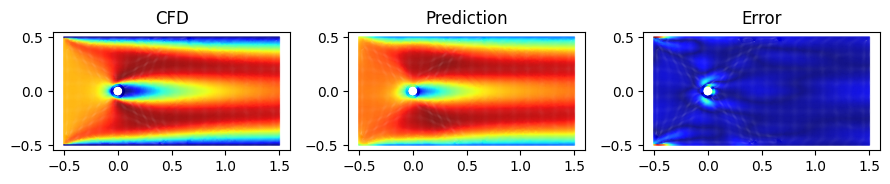

```python
with torch.no_grad():
    test_model_v1 = torch.load('/content/drive/MyDrive/DL/DL_data/model_v1.pt')

    u = U_test[0]
    Y = Y_test
    GT = GT_test[0]

    U = u * np.ones((len(Y), 1))
    U, Y = requires_grad(U), requires_grad(Y)

    pred = test_model_v1(U, Y)

    plt.figure(figsize = (9, 2))
    plt.subplot(1, 3, 1)
    plt.title('CFD')
    plt.scatter(Y[:, 0].detach().cpu().numpy(), Y[:, 1].detach().cpu().numpy(), c = GT[:, 0:1], s = 0.1, cmap = 'jet')
    plt.axis('scaled')

    plt.subplot(1, 3, 2)
    plt.title('Prediction')
    plt.scatter(Y[:, 0].detach().cpu().numpy(), Y[:, 1].detach().cpu().numpy(), c = pred.detach().cpu().numpy(), s = 0.1, cmap = 'jet')
    plt.axis('scaled')

    plt.subplot(1, 3, 3)
    plt.title('Error')
    plt.scatter(Y[:, 0].detach().cpu().numpy(), Y[:, 1].detach().cpu().numpy(), c = np.abs(pred.detach().cpu().numpy() - GT[:,0:1]), s = 0.1, cmap = 'jet')
    plt.axis('scaled')
    plt.tight_layout()
    plt.show()
```

## 5.4. Fast Computational Accelerator

We have demonstrated PI-DeepONet using the flow around a cylinder example. For an unseen viscosity value, the trained model can infer and predict the flow velocity field and pressure field.

This framework serves as a fast computational accelerator (or an AI-based surrogate model), significantly reducing the computational cost compared to traditional numerical simulations.

[figure not shown]

```python
%%javascript
$.getScript('https://kmahelona.github.io/ipython_notebook_goodies/ipython_notebook_toc.js')
```